# [**cellcontacts**](https://github.com/juliaquach02/cellcontacts)

Julia Quach

2023-08-20

# **About**

This R package was written to process imaging files acquired from live-cell imaging of T cells and tumour cells. It requires the prior analysis of the live-cell imaging sequences with a cell tracking tool, e.g., [TrackMate](https://imagej.net/plugins/trackmate/) or [Imaris](https://imaris.oxinst.com/products/imaris-for-tracking). It offers functions to compute cell-cell distances, cell-cell contacts, and characteristics of cell-cell interaction. Moreover, it allows to connect the results to immunohistochemical staining results.

# **Goal of the project**

The goal of this R package is to enable the quantitative analysis of T cell-tumour cell interaction in live cell imaging sequences

# **Installation**

The latest development version of cellcontacts can be installed from GitHub:

```r
devtools::install_github( "juliaquach02/cellcontacts" )
```

The package can be loaded via:

```r
library( cellcontacts )
```

# **Work flow**

The package was built to analyze 2D live-cell imaging movies. Before using the package, the cells need to segmented and tracked, for example using the Fiji plugin [TrackMate](https://imagej.net/plugins/trackmate/) by Tinevez at al (Tinevez et al. 2017).

The cellcontacts package processes

- ROIs representing segmented cells which are saved as .roi-files in a zipped folder, and
- cell tracks which are saved as .csv file with the columns “Label”, “X”, “Y”, “Frame”.

### **Preprocessing**

For the segmentation and tracking of the cells in the live-cell imaging film, TrackMate proves to be a useful tool. It is a modular tool that enables the segmentation and tracking of cells via common segmentation tools, e.g. [StarDist](https://imagej.net/plugins/stardist), and tracking tools, e.g. the [LAP tracker](https://www.nature.com/articles/nmeth.1237).

The cellcontacts package requires the segmentation and tracking of tumour and T cells as two separate cell populations. Cell areas, called cell ROIs (region of interest), should be named by their track name with index in the format *Track_[id]_[index]* and saved as .roi-files in a zipped folder. In addition, cell tracks should be saved as .csv file.

To ensure correct import of the data in RStudio, please make sure that file names do not contain a “.” and that only the first line of the .csv file contain column headers.

### **Setting directories and loading the data**

After setting source and destination directories, we can load the data into RStudio. To import the cell tracks, we simply use the `read.table()` function. To import the cell ROIs, we use the `read.ijzip()` function from the [RImageJROI](https://cran.r-project.org/web/packages/RImageJROI/index.html) package.

As the number of ROIs might be very large, it might be necessary to split the zipped ROIs into multiple zipped subfolders and load the folders in parallel using the [future](https://cran.r-project.org/web/packages/future/index.html) package. To save the ROIs into separate subfolders, an ImageJ macro is provided here.

Below, the code to load the tumour cell tracks and tumour cell ROIs is displayed. Analogously, we can load the T cell tracks and T cell ROIs.

```r
# Importing tracks
tumourTracksTxt <- read.table( tumourTracksPath, header = TRUE, sep = ",", )

# Load tumour ROIs of movie
# Create list of zipped ROI folders (Adjust numSubfolders for each data set)
numTumourSubfolders <- 14
pathROIs <- list()

for( i in 1:numTumourSubfolders){
  pathROIs[[i]] <- paste0(tumourROIsPath, as.character(i-1), ".zip")
}

# Subdivide list into two lists to create two jobs
pathROIsPt1 <- pathROIs[ 1:floor(numTumourSubfolders/2) ]
pathROIsPt2 <- pathROIs[ (floor(numTumourSubfolders/2) + 1):numTumourSubfolders ]

# Load ROIs in parallel
plan(multisession)

ROIsPt1 %<-% {  # job 1
  ROIsPt1 <- lapply( pathROIsPt1, read.ijzip)
}
ROIsPt2 %<-%{ # job 2
  ROIsPt2 <- lapply( pathROIsPt2, read.ijzip)
}

tumourROIs <- append( ROIsPt1, ROIsPt2)


# Load endpoint data ----------------------------------------------------

endPointROIs <- read.ijzip( endPointROIPath )
endPointMeasTxt <- read.table( endPointMeasPath, header = TRUE, sep = ",", )
```

### **Analysis**

To process a large set of segmented cells, we need to put the data into a suitable data structure to allow easy and efficient computation and access.

### 1. Matching track names to their frame number

Using the function `matchTrackNamesWithFrameNum()`, we assign the cell ROIs to their corresponding frame number.

```r
tumour_trackName_frameNum <- matchTrackNamesWithFrameNum( tumourTracksTxt )
tcell_trackName_frameNum <- matchTrackNamesWithFrameNum( tcellTracksTxt )

print( head( tumour_trackName_frameNum ))
```

```
##     TrackName Frame
## 1 Track_0-117   116
## 2 Track_0-125   124
## 3  Track_0-21    20
## 4 Track_0-153   152
## 5  Track_0-51    50
## 6 Track_0-148   147
```

```r
print( head( tcell_trackName_frameNum ))
```

```
##    TrackName Frame
## 1 Track_0-62    61
## 2 Track_0-96    95
## 3 Track_0-45    44
## 4 Track_0-28    27
## 5 Track_0-88    87
## 6  Track_0-4     3
```

### 2. Putting data into hash maps

To efficiently access our data during computation, we arrange our data set into hash maps. Furthermore, we sort the cell ROIs into a 2D grid with a column and row width of 100 µm to get rough estimates of their position.

To create a 2D grid, we provide the function `create_grid()`. To put the data into hash maps, we provide the functions

- `insert_Hashmap_FrameNumToNames()` to retrieve track names of all cells for a specific time point.
- `insert_Hashmap_NamesToCenter()` to retrieve the center point for a specific ROI name.
- `insert_Hashmap_NamesToGrid()` to retrieve a rough position in the frame for a specific ROI name.
- `insert_Hashmap_NamesToCoords()` to retrieve the ROI coordinates for a specific ROI name

```r
# Hash map from names to coordinates
tumourROImap <- hashmap( default = "No value for this key")
invisible( lapply( tumourROIs, insert_Hashmap_NamesToCoords, ROImap = tumourROImap) )

tcellROImap <- hashmap( default = "No value for this key")
invisible(  lapply( tcellROIs, insert_Hashmap_NamesToCoords, ROImap = tcellROImap)  )

# Hash map from time points to names
insert_Hashmap_FrameNumToNames( tumour_trackName_frameNum, ROImap = tumourROImap )
insert_Hashmap_FrameNumToNames( tcell_trackName_frameNum, ROImap = tcellROImap )

# Hash map from names to center points
tumourROImap_center <- hashmap( default = "No value for this key")
tcellROImap_center <- hashmap( default = "No value for this key")

invisible( lapply( tumourROIs, insert_Hashmap_NamesToCenter, ROImap = tumourROImap_center ) )
invisible( lapply( tcellROIs, insert_Hashmap_NamesToCenter, ROImap = tcellROImap_center ) )

# Hash map from names to position in grid
grid <- create_grid( c(0,600), c(0,600), dim = 6) ### Frame dimensions should be checked for each data set

tumourROImap_NamesToGrid <- hashmap( default = "No value for this key")
tcellROImap_NamesToGrid <- hashmap( default = "No value for this key")

invisible( lapply( tumourROIs, insert_Hashmap_NamesToGrid, ROImap = tumourROImap_NamesToGrid, grid = grid ) )
invisible( lapply( tcellROIs, insert_Hashmap_NamesToGrid, ROImap = tcellROImap_NamesToGrid, grid = grid ) )

# Add endPointROIs into field and hash map
endpointROImap <- hashmap( default = "No value for this key")
insert_Hashmap_NamesToCoords( endPointROIs, endpointROImap)
insert_Hashmap_NamesToGrid( endPointROIs, ROImap = tumourROImap_NamesToGrid, grid = grid  )
```

### 3. Mapping tracks to endpoint staining

We often want to connect the dynamic information of the cell tracks to the static information of the same cells from immunological staining. For this, we provide the function `match_to_endpoint_ROIs()` to match the cell tracks to the corresponding cell ROIs at the end point. The function `add_meas_to_matches()` can add the measurements of the signal intensity to the mapping of cell tracks to endpoint ROIs.

```r
# Map tumour tracks from movie to endpoint staining
matches <- match_to_endpoint_ROIs(  endPointROIs, endpointROImap, tumourROImap, tumourROImap_center, tumourROImap_NamesToGrid )

# Add measurement results to matches
result <- add_meas_to_matches( matches, endPointMeasTxt )
print( head( result ) )
```

```
##   endpoint_cell  movies_cell Area      Mean   Min   Max
## 2             2 Track_10-155  544 24376.570  4375 63320
## 3             3  Track_5-155  451 14991.359  5364 21044
## 4             4  Track_1-155  593  7780.622  3233 10774
## 5             5  Track_2-155  347  8440.568  4352 11136
## 6             6 Track_178-23  190 29328.805 10126 57951
## 7             7 Track_71-155  242 11620.851  6800 15060
```

To check the mapping, we can plot the matched endpoint ROIs and cell tracks by their color in one plot:

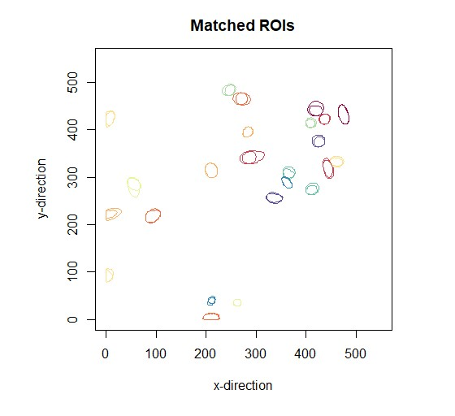

*Cell areas at last time point are mapped to the cell areas from the immunological staining at the endpoint. Matched cells are plotted in the same color.*

### 4. Computing cell-cell distances

Cell-cell distances need to be computed to filter for cell-cell contacts. For this, we provide the function `compute_distTimepoint_wGrid()`.

This function computes for a given time point all possible tumour cell/T cell pairs. For each pair, the function checks the rough position of both cells using their position in the 2D grid. If the cells are at least in neighboring columns and rows of the grid, the euclidean distance between the cell ROI is computed.

The output of the function is a data frame which lists all possible cell pairs and either the distance of the pair or a remark that the distance is substantially larger than the distance threshold for a cell-cell contact.

```r
cellDist <- lapply( 0: tumourROImap[["lastTimepoint"]], compute_distTimepoint_wGrid,
                              gridWidth = 100,
                              ROImap1 = tumourROImap,
                              ROImap2 = tcellROImap,
                              ROImapField1 = tumourROImap_NamesToGrid,
                              ROImapField2 = tcellROImap_NamesToGrid )

print( head(cellDist[[1]]) )
```

```
##        Var1      Var2 distances
## 1 Track_0-1 Track_0-1     >>100
## 2 Track_1-1 Track_0-1     >>100
## 3 Track_2-1 Track_0-1     >>100
## 4 Track_3-1 Track_0-1     >>100
## 5 Track_4-1 Track_0-1     >>100
## 6 Track_5-1 Track_0-1     >>100
```

### 5. Filtering for cell-cell contacts

To filter the cell pairs for cell-cell contacts, we only keep cell pairs that maintain a distance below a distance threshold for a minimum duration of frames. The distance and duration threshold can be set manually.

```r
# Set a thresholds for the minimum duration and distance of a contact
minDuration <- 3
distThresh <- 1

# Filter for cell-cell contacts using pipes from the tidyverse package
pairs <-  cellDist %>%
    add_columnPair() %>%
    lapply( add_columnTimepoint, tumour_trackName_frameNum = tumour_trackName_frameNum) %>%
    bind_rows(., .id = "column_label") %>%
    check_contacts( distThresh = distThresh ) %>%
    split( ., .$pair ) %>%
    lapply( ., get_pairs_wROInames, minimumDuration = minDuration) %>%
    bind_rows(., .id = "column_label")

print( head( pairs ) )
```

```
##        column_label startTime endTime duration              pair
## 1 Track_10-Track_15         1       3        2 Track_10-Track_15
## 2 Track_10-Track_15         6      17       11 Track_10-Track_15
## 3 Track_10-Track_35         9      22       13 Track_10-Track_35
## 4 Track_10-Track_35        24      31        7 Track_10-Track_35
## 5 Track_10-Track_58        34      36        2 Track_10-Track_58
## 6 Track_10-Track_65        41      47        6 Track_10-Track_65
##                                                                                                                                     tumourCell
## 1                                                                                                             Track_10-2,Track_10-3,Track_10-4
## 2 Track_10-7,Track_10-8,Track_10-9,Track_10-10,Track_10-11,Track_10-12,Track_10-13,Track_10-14,Track_10-15,Track_10-16,Track_10-17,Track_10-18
## 3          Track_10-10,Track_10-11,Track_10-12,Track_10-13,Track_10-14,Track_10-18,Track_10-19,Track_10-20,Track_10-21,Track_10-22,Track_10-23
## 4                                              Track_10-25,Track_10-26,Track_10-27,Track_10-28,Track_10-29,Track_10-30,Track_10-31,Track_10-32
## 5                                                                                                          Track_10-35,Track_10-36,Track_10-37
## 6                                                          Track_10-42,Track_10-43,Track_10-44,Track_10-45,Track_10-46,Track_10-47,Track_10-48
##                                                                                                                                          Tcell
## 1                                                                                                             Track_15-2,Track_15-3,Track_15-4
## 2 Track_15-7,Track_15-8,Track_15-9,Track_15-10,Track_15-11,Track_15-12,Track_15-13,Track_15-14,Track_15-15,Track_15-16,Track_15-17,Track_15-18
## 3                   Track_35-1,Track_35-2,Track_35-3,Track_35-4,Track_35-5,Track_35-6,Track_35-7,Track_35-8,Track_35-9,Track_35-10,Track_35-11
## 4                                              Track_35-13,Track_35-14,Track_35-15,Track_35-16,Track_35-17,Track_35-18,Track_35-19,Track_35-20
## 5                                                                                                             Track_58-1,Track_58-2,Track_58-3
## 6                                                                 Track_65-1,Track_65-2,Track_65-3,Track_65-4,Track_65-5,Track_65-6,Track_65-7
```

### 6. Validation and export of results

To check of the computed cell-cell contacts, we export the track information of the T cells that were in contact as .csv-file using `prepare_export_contacts_for_df_wROInames()` and `write.csv()`.

```r
# Export computed contacts as .csv
tcellTracksTxt_contact <- prepare_export_contacts_for_df_wROInames( pairs, tcellTracksTxt, cellType = "TCell")
write.csv( tcellTracksTxt_contact, paste0(resultsPath, "Tracks_T_Cells_in_contact.csv"), row.names=FALSE)
```

The exported files are loaded into TrackMate via ImageJ > Plugins > Tracking > TrackMate CSV Importer. Using the .csv file, TrackMate labels the T cells in the .tif-file only *during* a contact.

This allows us to revisit the live-cell imaging film and to check whether cell-cell contacts are correctly computed.

[figure not shown]

*Via the TrackMate CSV Importer GUI, we can load our results back into a TrackMate session. For this, we choose the image and the .csv file. For the .csv file, we add information on the content of its columns.*

# **Data**

The example folder contains the following files:

- Segmented cell ROIs for tumour and T cells in multiple zipped folders
- Cell tracks for tumour and T cells as .csv files
- The TrackMate sessions for tumour cells and T cells saved as .xml files
- Results of an immunological staining image of the tumour cells and T cells at the endpoint of the live-cell imaging film with a DAPI, phalloidin and p21 channel as .csv file.
- The R script to run the above mentioned analyses.

For more questions and remarks, feel free to open an issue on GitHub.

# **References**

Tinevez, Jean-Yves, Nick Perry, Johannes Schindelin, Genevieve M. Hoopes, Gregory D. Reynolds, Emmanuel Laplantine, Sebastian Y. Bednarek, Spencer L. Shorte, and Kevin W. Eliceiri. 2017. “TrackMate: An Open and Extensible Platform for Single-Particle Tracking.” Journal Article. *Methods* 115: 80–90. https://doi.org/https://doi.org/10.1016/j.ymeth.2016.09.016.